# Project: Data-driven Insights using Python: FoodHub Data Analysis

# Problem Statement

## Context

The number of restaurants in New York is increasing day by day. Lots of students and busy professionals rely on those restaurants due to their hectic lifestyles. An online food delivery service is a great option for them. It provides them with good food from their favorite restaurants. A food aggregator company FoodHub, offers access to multiple restaurants through a single smartphone app. The app allows the restaurants to receive a direct online order from a customer. The app assigns a delivery person from the company to pick up the order after it is confirmed by the restaurant. The delivery person then uses the map to reach the restaurant and waits for the food package. Once the food package is handed over to the delivery person, he/she confirm the pick-up in the app and travel to the customer's location to deliver the food. The delivery person confirms the drop-off in the app after delivering the food package to the customer. The customer can rate the order in the app. The food aggregator earns money by collecting a fixed margin of the delivery order from the restaurants.

## Objective

The food aggregator company has stored the data of the different orders made by the registered customers in its online portal. They want to analyze the data to get a fair idea about the demand for different restaurants, which will help them enhance their customer experience. Suppose you are hired as a Data Scientist in this company, and the Data Science team has shared some of the key questions that need to be answered. Perform the data analysis to find answers to these questions that will help the company improve its business.

## Data Description

The data contains different data related to a food order. The detailed data dictionary is given below.

- order_id: Unique ID of the order
- customer_id: ID of the customer who ordered the food
- restaurant_name: Name of the restaurant
- cuisine_type: Cuisine ordered by the customer
- cost_of_the_order: Cost of the order
- day_of_the_week: Indicates whether the order is placed on a weekday or weekend (The weekday is from Monday to Friday and the weekend is Saturday and Sunday)
- rating: Rating given by the customer out of 5
- food_preparation_time: Time (in minutes) taken by the restaurant to prepare the food. This is calculated by taking the difference between the timestamps of the restaurant's order confirmation and the delivery person's pick-up confirmation.
- delivery_time: Time (in minutes) taken by the delivery person to deliver the food package. This is calculated by taking the difference between the timestamps of the delivery person's pick-up confirmation and drop-off information

# Let us start by importing the required libraries

```python
# Installing the libraries with the specified version.
!pip install numpy==1.25.2 pandas==1.5.3 matplotlib==3.7.1 seaborn==0.13.1 -q --user
```

[output not shown]

**Note**:

- After running the above cell, kindly restart the runtime (for Google Colab) or notebook kernel (for Jupyter Notebook), and run all cells sequentially from the next cell.
- On executing the above line of code, you might see a warning regarding package dependencies. This error message can be ignored as the above code ensures that all necessary libraries and their dependencies are maintained to successfully execute the code in **this notebook**.

```python
# Import libraries for data manipulation
import numpy as np
import pandas as pd

# Import libraries for data visualization
import matplotlib.pyplot as plt
import seaborn as sns
```

# Understanding the structure of the data

```python
# uncomment and run the below code snippets if the dataset is present in the Google Drive
from google.colab import drive
drive.mount('/content/drive')
```

```python
 # Navigate to the directory where FoodHub_Project_Learner_Notebook_Full_Code.ipynb is located
%cd '/content/drive/MyDrive/Colab_Notebooks'
```

```
/content/drive/MyDrive/Colab_Notebooks
```

```python
#convert ipynb to html file
!jupyter nbconvert FoodHub_Project_Learner_Notebook_Full_Code.ipynb --
```

[output not shown]

```python
# Reading data from My Google Drive
foodhub = pd.read_csv("/content/drive/MyDrive/UTA_PGP_DSGA/foodhub_order.csv")
```

```python
# View the first 5 rows
foodhub.head()
```

|  | order_id | customer_id | restaurant_name | cuisine_type | cost_of_the_order | day_of_the_week | rating | food_preparation_time | delivery_time |
| --- | --- | --- | --- | --- | --- | --- | --- | --- | --- |
| 0 | 1477147 | 337525 | Hangawi | Korean | 30.75 | Weekend | Not given | 25 | 20 |
| 1 | 1477685 | 358141 | Blue Ribbon Sushi Izakaya | Japanese | 12.08 | Weekend | Not given | 25 | 23 |
| 2 | 1477070 | 66393 | Cafe Habana | Mexican | 12.23 | Weekday | 5 | 23 | 28 |
| 3 | 1477334 | 106968 | Blue Ribbon Fried Chicken | American | 29.20 | Weekend | 3 | 25 | 15 |
| 4 | 1478249 | 76942 | Dirty Bird to Go | American | 11.59 | Weekday | 4 | 25 | 24 |

### **Question 1:** How many rows and columns are present in the data? [0.5 mark]

```python
# Finding the rows and columns of the dataframe foodhub
foodhub.shape
```

```
(1898, 9)
```

#### Observations:

1. This foodhub dataset has 1898 rows and 9 columns. It contains information about various food online orders placed on FooodHub - an aggregator company - via its smartphone app.
2. The data set tells us the restaurant name . type of cuisine, order cost, which day of the week it was placed , what rating the customer gave for the ordered food , and its food preparation time and delivery time.
3. Order ID is teh unique identifier for each order and customer ID is teh unique identifer for that customer.

### **Question 2:** What are the datatypes of the different columns in the dataset? (The info() function can be used) [0.5 mark]

```python
# Find the data type, non null count for each column of the dataset Foodhub
foodhub.info()
```

```
<class 'pandas.core.frame.DataFrame'>
RangeIndex: 1898 entries, 0 to 1897
Data columns (total 9 columns):
 #   Column                 Non-Null Count  Dtype
---  ------                 --------------  -----
 0   order_id               1898 non-null   int64
 1   customer_id            1898 non-null   int64
 2   restaurant_name        1898 non-null   object
 3   cuisine_type           1898 non-null   object
 4   cost_of_the_order      1898 non-null   float64
 5   day_of_the_week        1898 non-null   object
 6   rating                 1898 non-null   object
 7   food_preparation_time  1898 non-null   int64
 8   delivery_time          1898 non-null   int64
dtypes: float64(1), int64(4), object(4)
memory usage: 133.6+ KB
```

#### Observations:

1. Columns order_id, customer_id, cost_of_the_order, food_preparation_time,delivery_time are set as int64 and float64. So these are numerical value.
2. Columns restaurant_name, cuisine_type, day_of_the_week, rating are categorical columns.
3. All the columns have 1898 observations which means none of the columns have null values.

### **Question 3:** Are there any missing values in the data? If yes, treat them using an appropriate method. [1 mark]

```python
# Find the missing value count in the dataset
missing_count = foodhub.isnull().sum().reset_index()
missing_count.columns = ["Column Name", "Missing Value Count"]
print(missing_count)
```

```
             Column Name  Missing Value Count
0               order_id                    0
1            customer_id                    0
2        restaurant_name                    0
3           cuisine_type                    0
4      cost_of_the_order                    0
5        day_of_the_week                    0
6                 rating                    0
7  food_preparation_time                    0
8          delivery_time                    0
```

#### Observations:

- The output displays the Column Name and the count of missing values for each of those columns.
- As each of the count is 0 , there are no missing values in the dataset.

### **Question 4:** Check the statistical summary of the data. What is the minimum, average, and maximum time it takes for food to be prepared once an order is placed? [2 marks]

```python
# Find statistical summary of foodhub
foodhub.describe()
```

|  | order_id | customer_id | cost_of_the_order | food_preparation_time | delivery_time |
| --- | --- | --- | --- | --- | --- |
| count | 1.898000e+03 | 1898.000000 | 1898.000000 | 1898.000000 | 1898.000000 |
| mean | 1.477496e+06 | 171168.478398 | 16.498851 | 27.371970 | 24.161749 |
| std | 5.480497e+02 | 113698.139743 | 7.483812 | 4.632481 | 4.972637 |
| min | 1.476547e+06 | 1311.000000 | 4.470000 | 20.000000 | 15.000000 |
| 25% | 1.477021e+06 | 77787.750000 | 12.080000 | 23.000000 | 20.000000 |
| 50% | 1.477496e+06 | 128600.000000 | 14.140000 | 27.000000 | 25.000000 |
| 75% | 1.477970e+06 | 270525.000000 | 22.297500 | 31.000000 | 28.000000 |
| max | 1.478444e+06 | 405334.000000 | 35.410000 | 35.000000 | 33.000000 |

#### Observations:

1. It takes minimum 20 minutes and maximum 35 minutes for food preparation
2. On an average approx 27 minutes is taken for food preparation
3. 50% of the orders take 27 minutes for food preparation
4. Cost of the orders range between 4 dollars to 35 dollars.
5. Average cost of the orders is around 16 dollars

### **Question 5:** How many orders are not rated? [1 mark]

```python
# Find the not rated orders by value_counts. value_counts will give the count of rows for each rating value.
# As the order ids are unique the count column gives the right count of orders not rated
foodhub['rating'].value_counts().reset_index()
```

|  | rating | count |
| --- | --- | --- |
| 0 | Not given | 736 |
| 1 | 5 | 588 |
| 2 | 4 | 386 |
| 3 | 3 | 188 |

#### Observations:

- 736 orders are not rated
- 588 with rating 5, 386 with rating 4 , 188 with rating 3
- As the order ids are unique the count column gives the right count of orders not rated

# Exploratory Data Analysis (EDA)

## Univariate Analysis

### **Question 6:** Explore all the variables and provide observations on their distributions. (Generally, histograms, boxplots, countplots, etc. are used for univariate exploration.) [9 marks]

#### **Order ID**

```python
# Unique Order ID
foodhub['order_id'].nunique()
```

```
1898
```

#### **Customer ID**

```python
# Unique Customer ID
foodhub['customer_id'].nunique()
```

```
1200
```

#### **Restaurant Name**

```python
# Unique Restaurant Name
foodhub['restaurant_name'].nunique()
```

```
178
```

#### **Cuisine Type**

```python
# Unique Cuisine Type
foodhub['cuisine_type'].nunique()
```

```
14
```

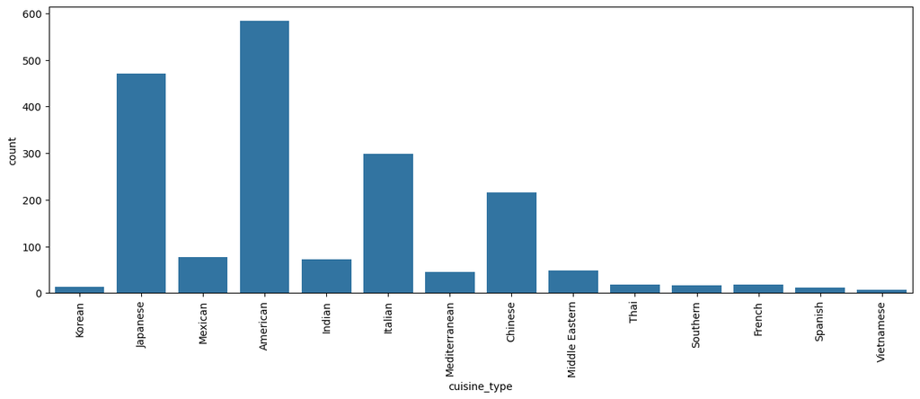

```python
plt.figure(figsize=(15,5))
sns.countplot(data=foodhub, x='cuisine_type')
plt.xticks(rotation=90)
plt.show()
```

#### **Cost of the Order**

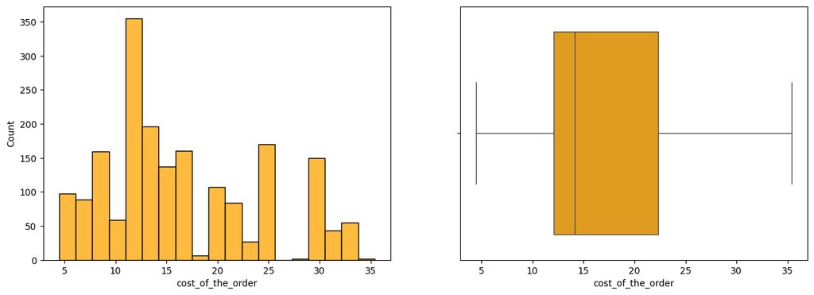

```python
# Display the distribution of order cost
fig, axes = plt.subplots(1,2,figsize=(15,5))
sns.histplot(data=foodhub, x='cost_of_the_order', ax=axes[0], color='Orange')
sns.boxplot(data=foodhub, x='cost_of_the_order', ax=axes[1], color='Orange')
plt.show()
```

#### **Day of the Week**

```python
# Display the unique day of the week values
foodhub['day_of_the_week'].nunique()
```

```
2
```

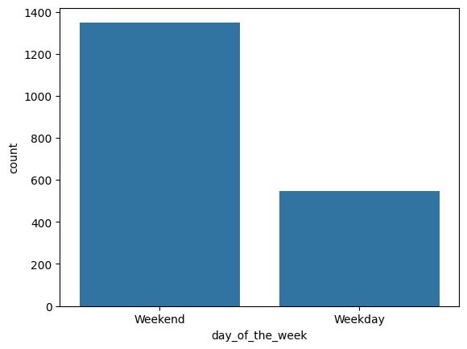

```python
# Display the distribution of Weekend or Weekday when the order was placed
sns.countplot(data=foodhub, x = 'day_of_the_week');
```

#### **Rating**

```python
# Display the unique day of the week values
foodhub['rating'].nunique()
```

```
4
```

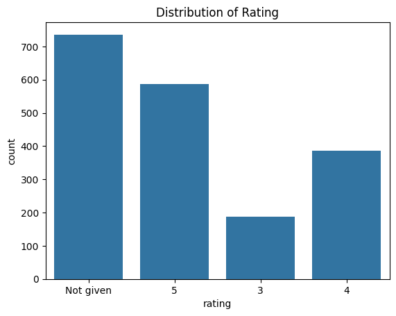

```python
# Display the distribution of rating for the orders
sns.countplot(data=foodhub, x = 'rating');
plt.title('Distribution of Rating')
```

#### **Food Preparation Time**

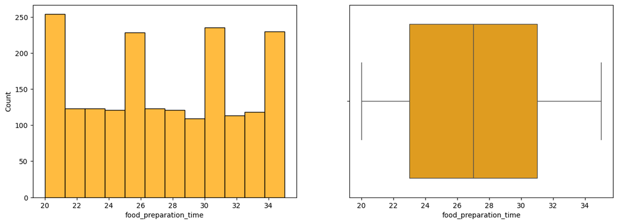

```python
# Display the distribution of food preparation time
fig, axes = plt.subplots(1,2,figsize=(15,5))
sns.histplot(data=foodhub, x='food_preparation_time', ax=axes[0], color='Orange')
sns.boxplot(data=foodhub, x='food_preparation_time', ax=axes[1], color='Orange')
plt.show()
```

#### **Delivery Time**

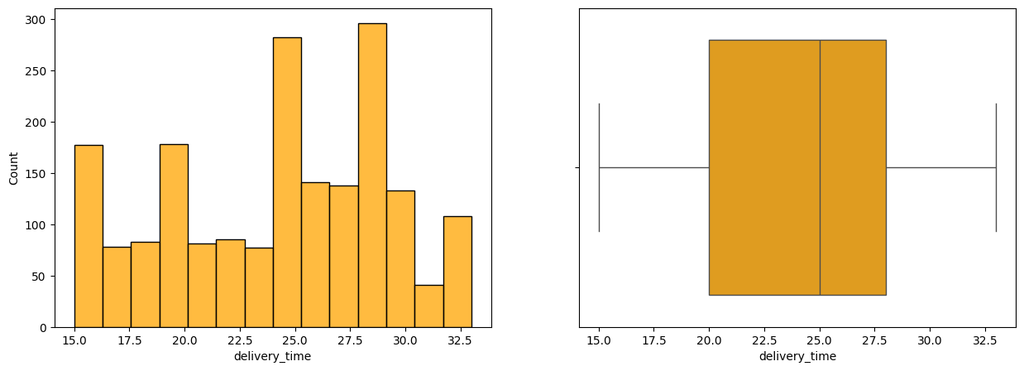

```python
# Display the distribution of delivery time
fig, axes = plt.subplots(1,2,figsize=(15,5))
sns.histplot(data=foodhub, x='delivery_time', ax=axes[0], color='Orange')
sns.boxplot(data=foodhub, x='delivery_time', ax=axes[1], color='Orange')
plt.show()
```

### **Question 7**: Which are the top 5 restaurants in terms of the number of orders received? [1 mark]

```python
# Get top 5 restaurants with highest number of orders

top5_restaurants = foodhub.groupby('restaurant_name')['order_id'].count().sort_values(ascending=False).head(5)
top5_restaurants
```

| restaurant_name | order_id |
| --- | --- |
| Shake Shack | 219 |
| The Meatball Shop | 132 |
| Blue Ribbon Sushi | 119 |
| Blue Ribbon Fried Chicken | 96 |
| Parm | 68 |

**dtype:** int64

#### Observations:

1. Maximum orders were placed with Shake Shack(219) following The Meatball Shop(132) then Blue Ribbon Sushi(119) then Blue Ribbon Fried Chicken(96) and last of teh top 5 is Parm(68)
2. Approximately 33 percent(634) of the total orders(1898) were from these 5 restaurants.

### **Question 8**: Which is the most popular cuisine on weekends? [1 mark]

```python
# Most popular cuisine on weekday
# weekday = foodhub[foodhub['day_of_the_week'] == 'Weekday']
# popular_cuisine_weekday = weekday.groupby('cuisine_type')['order_id'].count().sort_values(ascending=False)
# popular_cuisine_weekday

# Most popular cuisine on weekend
weekend = foodhub[foodhub['day_of_the_week'] == 'Weekend']
popular_cuisine_weekend = weekend.groupby('cuisine_type')['order_id'].count().sort_values(ascending=False)
popular_cuisine_weekend
```

| cuisine_type | order_id |
| --- | --- |
| American | 415 |
| Japanese | 335 |
| Italian | 207 |
| Chinese | 163 |
| Mexican | 53 |
| Indian | 49 |
| Middle Eastern | 32 |
| Mediterranean | 32 |
| Thai | 15 |
| French | 13 |
| Korean | 11 |
| Southern | 11 |
| Spanish | 11 |
| Vietnamese | 4 |

**dtype:** int64

#### Observations:

1. American is the most popular cuisine in weekends
2. Followed by Japanese, Italian and Chinese.
3. Total 1351 orders were placed during weekends out of which 415 was american cuisines ordered which is almost 30 percent of the orders of weekend.

### **Question 9**: What percentage of the orders cost more than 20 dollars? [2 marks]

```python
# Percentage of orders costing more that 20 Dollars
orders_cost_more_than_20 = foodhub[foodhub['cost_of_the_order'] > 20]
orders_cost_more_than_20
percentage_orders_cost_more_than_20 = (len(orders_cost_more_than_20) / len(foodhub)) * 100
print("Percentage of orders costing more than 20 dollars is", round(percentage_orders_cost_more_than_20,2), "percent")
```

```
Percentage of orders costing more than 20 dollars is 29.24 percent
```

#### Observations:

1. Total 555 Orders costed more than 20 $
2. Calculated percentage no of rows in orders_cost_more_than_20 divided by no of rows in foodhub data frame multipled by 100 which is approx 29 percent

### **Question 10**: What is the mean order delivery time? [1 mark]

```python
# Write the code here
mean_delivery_time = foodhub['delivery_time'].mean()
print("The mean delivery time for foodhub data set is", round(mean_delivery_time,2), 'minutes')
```

```
The mean delivery time for foodhub data set is 24.16 minutes
```

#### Observations:

- Mean Delivery Time is 24.16 minutes approx

### **Question 11:** The company has decided to give 20% discount vouchers to the top 5 most frequent customers. Find the IDs of these customers and the number of orders they placed. [1 mark]

```python
# Write the code here
top5_customers = foodhub['customer_id'].value_counts().head(5).reset_index()
top5_customers.columns = ["Customer ID", "Order Count"]
top5_customers
```

|  | Customer ID | Order Count |
| --- | --- | --- |
| 0 | 52832 | 13 |
| 1 | 47440 | 10 |
| 2 | 83287 | 9 |
| 3 | 250494 | 8 |
| 4 | 259341 | 7 |

#### Observations:

1. Customer ID "52832" placed the maximum orders which is 13

## Multivariate Analysis

### **Question 12**: Perform a multivariate analysis to explore relationships between the important variables in the dataset and provide observations. (It is a good idea to explore relations between numerical variables as well as relations between numerical and categorical variables) [10 marks]

#### **Cuisine vs Cost of the order**

#### **Observations**

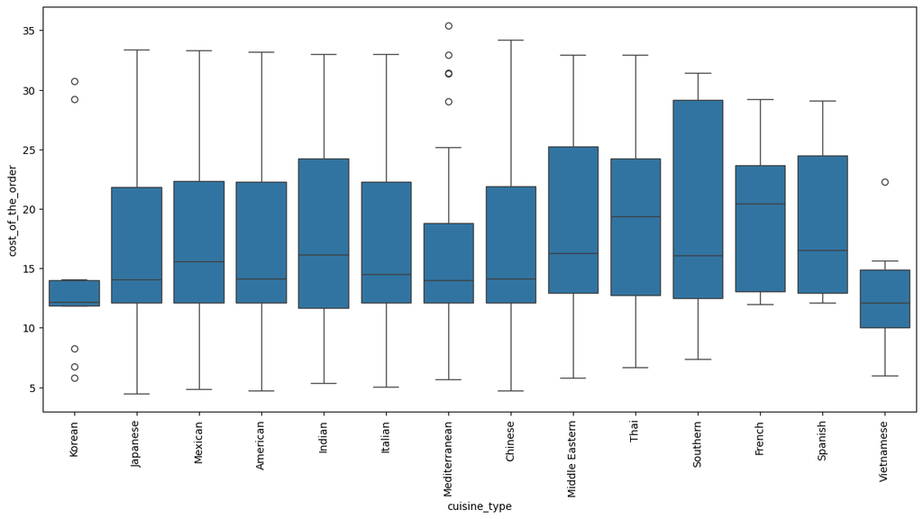

```python
# Cuisine vs Cost of the order
plt.figure(figsize=(15,7))
sns.boxplot(data=foodhub, x='cuisine_type', y='cost_of_the_order')
plt.xticks(rotation=90)
plt.show()
```

#### **Cuisine vs Food Preparation Time**

#### **Observations**

1. The boxplot shows that food preparation time varies slightly across cuisines
2. Most cuisines have median preparation time between 25-28 minutes
3. Thai, Southern and Japanese cuisines show higher variability in preparation times while korean cuisine appears more consitent with lower spread
4. A few outleirs are observed in korean cuisines indicating occassional delays
5. Overall cuisine type has a moderate influence on food preparation time

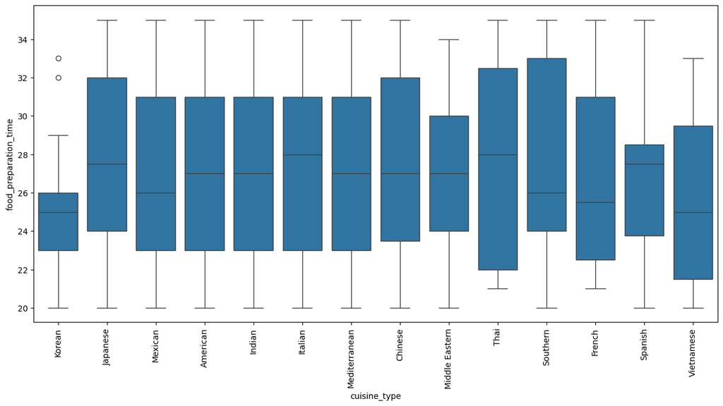

```python
# Cuisine vs Food Preparation Time
plt.figure(figsize=(15,7))
sns.boxplot(data=foodhub, x='cuisine_type', y='food_preparation_time')
plt.xticks(rotation=90)
plt.show()
```

#### **Observations**

1. Customers are most satisfied with Spanish, Thai, and Indian cuisines.
2. Although American cuisine has the highest number of orders, it does not have the highest customer ratings.

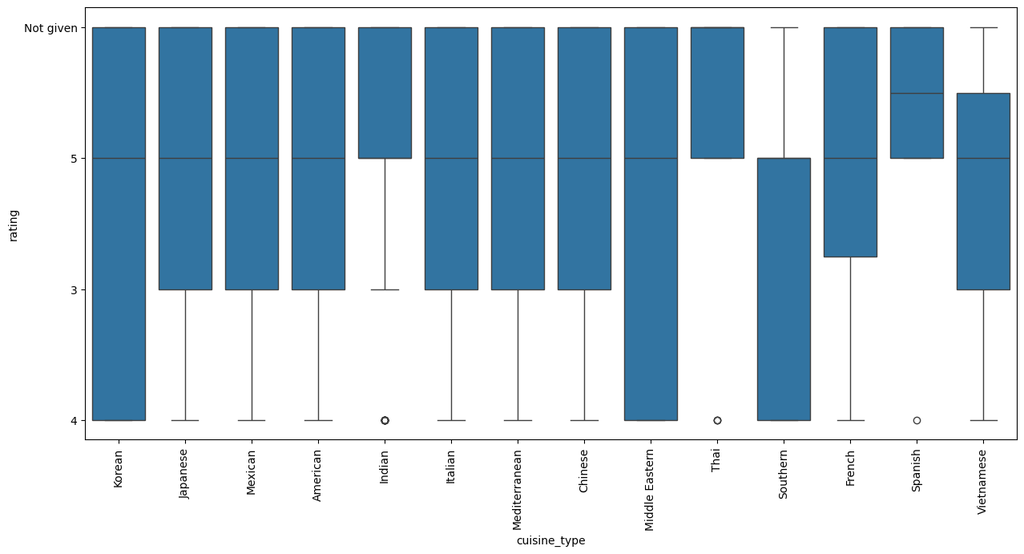

```python
# Cuisine vs Rating
plt.figure(figsize=(15,7))
sns.boxplot(data=foodhub, x='cuisine_type', y='rating')
plt.xticks(rotation=90)
plt.show()
```

#### **Cuisine Vs Delivery Time**

#### **Observations**

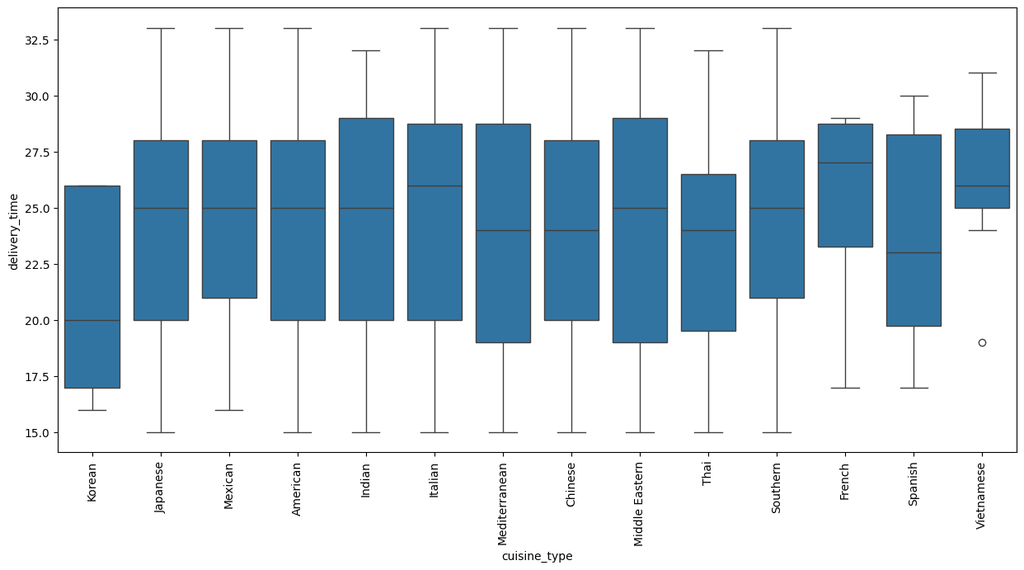

```python
# Cuisine vs Delivery Time
plt.figure(figsize=(15,7))
sns.boxplot(data=foodhub, x='cuisine_type', y='delivery_time')
plt.xticks(rotation=90)
plt.show()
```

#### **Day of the week vs Delivery Time**

#### **Observations**

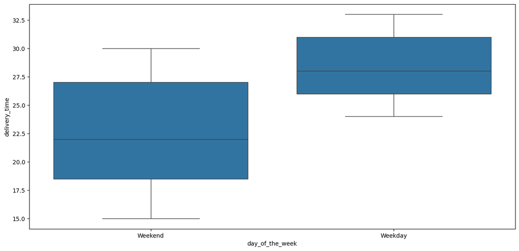

```python
# Day of the week vs Delivery Time
plt.figure(figsize=(15,7))
sns.boxplot(data=foodhub, x='day_of_the_week', y='delivery_time')
#plt.xticks(rotation=90)
plt.show()
```

#### **Day of the week vs Cost**

#### Observations

1. Spread is similar on weekdays and weekends
2. High-value orders occur on both weekdays and weekends
3. Customer spending behavior is stable throughout the week
4. Weekends are only slightly higher

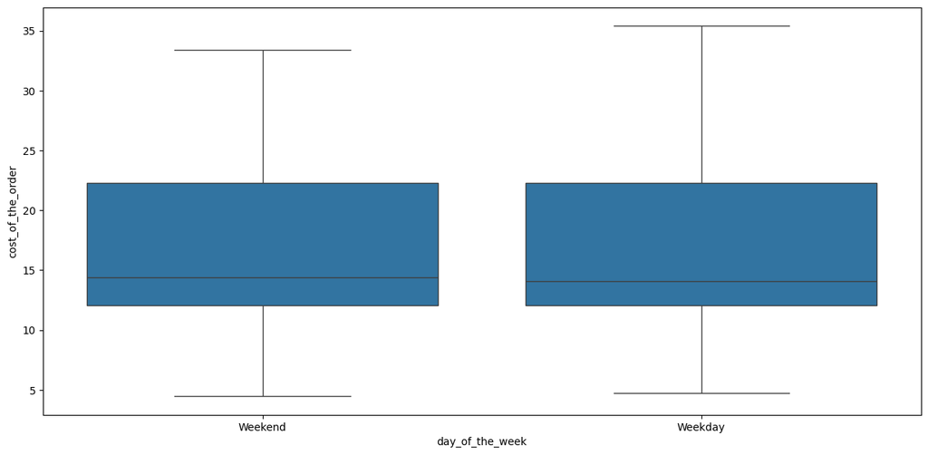

```python
# Day of the week versus Cost
plt.figure(figsize=(15,7))
sns.boxplot(data=foodhub, x='day_of_the_week', y='cost_of_the_order')
#plt.xticks(rotation=90)
plt.show()
```

#### **Rating vs Delivery Time**

#### **Observations**

1. delivery time does not vary significantly across customer ratings
2. Customers giving higher ratings did not necessarily receive much faster deliveries.

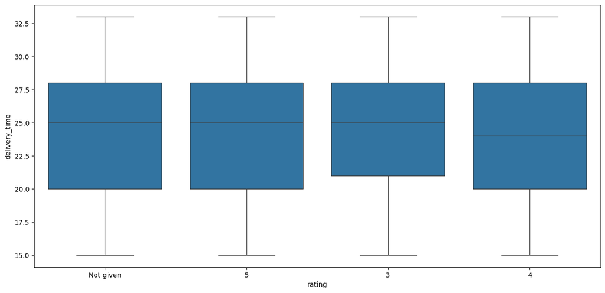

```python
# Rating vs Delivery Time
plt.figure(figsize=(15,7))
sns.boxplot(data=foodhub, x='rating', y='delivery_time')
#plt.xticks(rotation=90)
plt.show()
```

#### **Rating vs Food Preparation Time**

#### **Observations**

Customers who gave higher ratings did not receive noticeably faster food preparation.

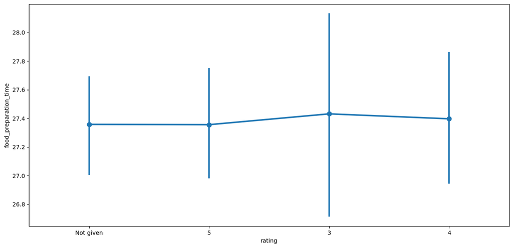

```python
# Rating vs Food Preparation Time
plt.figure(figsize=(15,7))
sns.pointplot(data=foodhub, x='rating', y='food_preparation_time')
plt.show()
```

#### **Rating vs Cost of the Order**

#### **Observations**

1. Higher-priced orders do not automatically receive better ratings - very slight approx 1 dollar increase or decrease in price with rating changes.

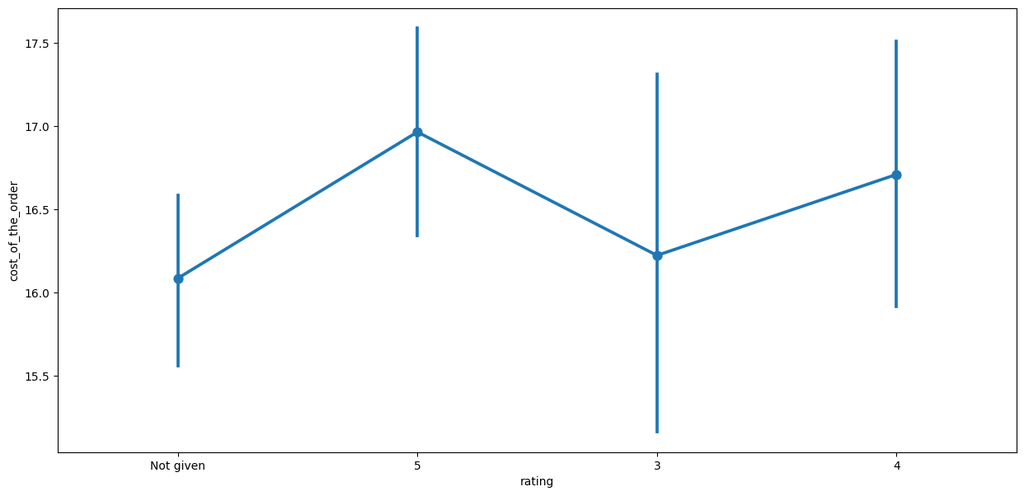

```python
# Rating vs Cost of the Order
plt.figure(figsize=(15,7))
sns.pointplot(data=foodhub, x='rating', y='cost_of_the_order')
plt.show()
```

#### **Revenue Generated by the Restaurants**

```python
# Find the revenue generated by the restaurants
foodhub.groupby('restaurant_name')['cost_of_the_order'].sum().sort_values(ascending=False).reset_index()
```

|  | restaurant_name | cost_of_the_order |
| --- | --- | --- |
| 0 | Shake Shack | 3579.53 |
| 1 | The Meatball Shop | 2145.21 |
| 2 | Blue Ribbon Sushi | 1903.95 |
| 3 | Blue Ribbon Fried Chicken | 1662.29 |
| 4 | Parm | 1112.76 |
| ... | ... | ... |
| 173 | Market Table | 6.79 |
| 174 | Wa Jeal | 6.74 |
| 175 | Big Wong Restaurant _¤¾Ñ¼ | 5.92 |
| 176 | Cipriani Le Specialita | 5.92 |
| 177 | Hunan Manor | 5.72 |

178 rows × 2 columns

#### **Correlation among variables**

#### **Observations**

1. Very weak positive correlation between Order Cost and food prep time of 0.04
2. Overall weak positive and negative correlation between avriables max 0.04 and min -0.03

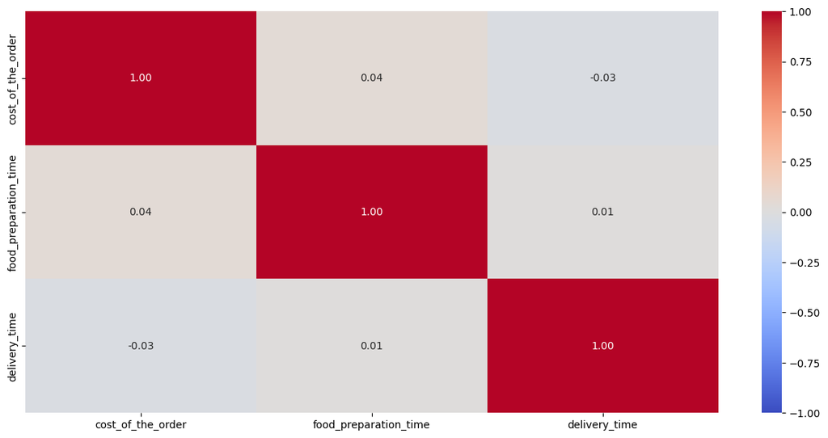

```python
# Finding correlation among the variables
col_List_corr = ['cost_of_the_order', 'food_preparation_time', 'delivery_time']
plt.figure(figsize=(15,7))
sns.heatmap(foodhub[col_List_corr].corr(), annot=True,vmin = -1, vmax = 1, fmt =".2f", cmap='coolwarm')
plt.show()
```

### **Question 13:** The company wants to provide a promotional offer in the advertisement of the restaurants. The condition to get the offer is that the restaurants must have a rating count of more than 50 and the average rating should be greater than 4. Find the restaurants fulfilling the criteria to get the promotional offer. [3 marks]

```python
# Create a copyfrom foodhub dataset with Restaurants having valid ratings
df_rated = foodhub[foodhub['rating'] != 'Not given'].copy()
# rated_restaurants

# Convert rating column from object to int type to do arithmentic operations
df_rated['rating'] = df_rated['rating'].astype('int')

# Find the restaurants with rating count of more than 50 from rated_restaurants_df
df_rating_count = df_rated.groupby('restaurant_name')['rating'].count().sort_values(ascending=False).reset_index()
#rated_restaurants_df

# Get the restaurants that have rating count more than 50
rest_names = df_rating_count[df_rating_count['rating'] > 50]['restaurant_name']
#rated_restaurants_mean

#  Get the restaurants data that have rating count more than 50
df_mean_4 = df_rated[df_rated['restaurant_name'].isin(rest_names)].copy()
#df_mean_4

# Find the mean ratings for all restaurants in rated_restaurants_df
df_mean_4_rating = df_mean_4.groupby('restaurant_name')['rating'].mean().sort_values(ascending= False).reset_index().dropna()
#df_mean_4_rating

# Find the average rating greater than 4
avg_greater_than_4 = df_mean_4_rating[df_mean_4_rating['rating'] > 4].sort_values(by='rating', ascending = False).reset_index(drop=True)
avg_greater_than_4
```

|  | restaurant_name | rating |
| --- | --- | --- |
| 0 | The Meatball Shop | 4.511905 |
| 1 | Blue Ribbon Fried Chicken | 4.328125 |
| 2 | Shake Shack | 4.278195 |
| 3 | Blue Ribbon Sushi | 4.219178 |

#### Observations:

1. Only a few restaurants have an average rating greater than 4
2. The Meatball shop ahs the highest average rating making it teh top rated restaurant among highly reviewed restaurants.
3. Blue Ribbon FC, Shae Shack, Blue Ribbon Sushi also maintain strong customer ratings above 4.
4. The ratings of these restaurants are relatively close , indicating consistent customer satisfaction among the top performers.

### **Question 14:** The company charges the restaurant 25% on the orders having cost greater than 20 dollars and 15% on the orders having cost greater than 5 dollars. Find the net revenue generated by the company across all orders. [3 marks]

```python
# Net Revenue across all orders
def revenue_calc(x):
  if x > 20:
    return x * 0.25
  elif x > 5:
    return x * 0.15
  else:
    return 0
foodhub['revenue'] = foodhub['cost_of_the_order'].apply(revenue_calc)
total_rev = foodhub['revenue'].sum()

print("The total revenue generated by the company across all orders is", round(total_rev,2), "dollars")
```

```
The total revenue generated by the company across all orders is 6166.3 dollars
```

#### Observations:

1. High cost orders contribute more towards recvenue of the company

### **Question 15:** The company wants to analyze the total time required to deliver the food. What percentage of orders take more than 60 minutes to get delivered from the time the order is placed? (The food has to be prepared and then delivered.) [2 marks]

```python
# Calculate total delivery time for each order
foodhub['total_delivery_time'] = foodhub['food_preparation_time'] + foodhub['delivery_time']

# Find the percentage of orders that takes more tha 60 minutes to get delivered
percentage_orders_more_than_60 = (len(foodhub[foodhub['total_delivery_time'] > 60]) / len(foodhub)) * 100
print("Percentage of orders that take more than 60 minutes to get delivered is", round(percentage_orders_more_than_60,2), "percent")
```

```
Percentage of orders that take more than 60 minutes to get delivered is 10.54 percent
```

#### Observations:

1. Considering the mean delivery time(Food prep+Delivery time), min and max values most deliveries are completed within a moderate tiem frame.
2. 10.54 % of orders taking more than 60 minutes indicate a noticeable proportion of customers experiencing significant delays.
3. The wide gap between minimum and maximum delivery times [35 to 68 minutes] suggest variability in delivery efficiency.
4. Orders taking more than 60 minutes may be influenced by peak hour traffic , high demand etc.

### **Question 16:** The company wants to analyze the delivery time of the orders on weekdays and weekends. How does the mean delivery time vary during weekdays and weekends? [2 marks]

```python
# Find out the mean delivery time variation during weekdays and weekends
foodhub.groupby('day_of_the_week')['delivery_time'].mean()

print("The mean delivery time during weekdays is", round(foodhub[foodhub['day_of_the_week'] == 'Weekday']['delivery_time'].mean(),2), "minutes")
print("The mean delivery time during weekends is", round(foodhub[foodhub['day_of_the_week'] == 'Weekend']['delivery_time'].mean(),2), "minutes")
```

```
The mean delivery time during weekdays is 28.34 minutes
The mean delivery time during weekends is 22.47 minutes
```

#### **Observations**:

1. Delivery Time is noticeably lower on weekends compared to weekdays.
2. This suggests that orders are delivered faster on weekends , possibly due to low traffic congestion, better delivery partner availability.
3. Higher weekday delivery times may indicate increased order volume or traffic related delays.

# Conclusion and Business Recommendations